# BCB420 Assignment 3 - Data set Pathway and Network Analysis

Arianne Beauregard

# Install and load required packages

```r
bioc <- c()
cran <- c("knitr", "kableExtra")

# install BiocManager if needed
if (!require("BiocManager", quietly = TRUE))
    install.packages("BiocManager")

# install bioconductor packages if necessary
for (package in bioc) {
  if (!require(package, character.only = TRUE)) {
    BiocManager::install(package)
    require(package)
  }
}

# install cran packages if necessary
for(package in cran) {
  if(!require(package, character.only = TRUE)){
    install.packages(package)
    require(package)
  }
}
```

# Introduction

The dataset is from a study of lipid remodeling in response to methionine stress in triple-negative breast cancer (TNBC) cells (Borrego et al., 2021). The dataset contains RNA-seq profiles of two TNBC cell lines, one methionine-sensitive cell line (MDA-MBA-468) its methionine-insensitive derivative (MDA-MB-468res-R8), responding to methionine stress. The data was downloaded from GEO Accession GSE155955.

In Assignment 1, the data was preprocessed and normalized. Gene identifiers were mapped to their HUGO Symbols. The data was normalized using Trimmed Mean of M-values (TMM).

In Assignment 2, a differential expression analysis was conducted with the normalized expression expression data using the edgeR package (Chen, Lun, and Smyth 2016). Two separate differential expression analyses were performed; one for cell line MDA-MB-468, and the other for cell line MDA-MB-468res-R8. Next, a thresholded gene set enrichment analysis was performed with the significantly up-regulated and down-regulated set of genes from the analyses using g:Profiler (Kolberg et al. 2020) and GO biological process terms. Three main term groups were returned: response to stimulus, cell death, and response to corticotropin-releasing hormone.

We will first read our data from Assignment 2. The file A2_data.rda contains `qlf_output_hits_MB468` and `qlf_output_hits_R8`, which are the results of the differential analyses for cell lines MDA-MB-468 and MDA-MB-468res-R8 respectively.

```r
load("../data/A2_data.rda")

# view data
kable(head(qlf_output_hits_MB468), type="html", caption = "Table 1. Head of ranked list for cell line MDA-MB-468") %>%
  kable_styling()
```

Table 1. Head of ranked list for cell line MDA-MB-468

|  | logFC | logCPM | F | PValue | FDR | expression |
| --- | --- | --- | --- | --- | --- | --- |
| ARHGAP25 | 3.163289 | 5.130631 | 54.28479 | 0.0000422 | 0.5522036 | upregulated |
| MIR3150BHG | -1.819568 | 5.615789 | 159.70188 | 0.0034787 | 0.9999987 | downregulated |
| TMEM156 | 1.900142 | 5.067277 | 45.32294 | 0.0039680 | 0.9999987 | upregulated |
| LINC01132 | -1.494168 | 5.910353 | 363.71472 | 0.0046508 | 0.9999987 | downregulated |
| PNPLA3 | -1.778051 | 5.461671 | 69.87417 | 0.0065440 | 0.9999987 | downregulated |
| DHRS2 | 1.079071 | 6.059821 | 486.10562 | 0.0079353 | 0.9999987 | upregulated |

```r
kable(head(qlf_output_hits_R8), type="html", caption = "Table 2. Head of ranked list for cell line MDA-MB-468res-R8") %>%
  kable_styling()
```

Table 2. Head of ranked list for cell line MDA-MB-468res-R8

|  | logFC | logCPM | F | PValue | FDR | expression |
| --- | --- | --- | --- | --- | --- | --- |
| TMEM238L | -3.035768 | 5.458397 | 63.59605 | 0.0002352 | 0.9999995 | downregulated |
| PNPLA3 | -3.210784 | 5.335627 | 65.87941 | 0.0002543 | 0.9999995 | downregulated |
| NR4A3 | -1.379894 | 6.511295 | 666.95121 | 0.0007123 | 0.9999995 | downregulated |
| TCIM | -2.508412 | 5.608795 | 81.25583 | 0.0009883 | 0.9999995 | downregulated |
| EGR4 | -2.186651 | 5.773591 | 150.59473 | 0.0010075 | 0.9999995 | downregulated |
| SH2D1A | -2.120030 | 5.682499 | 173.69510 | 0.0016231 | 0.9999995 | downregulated |

# Non-thresholded Gene set Enrichment Analysis

We will conduct a non-thresholded gene set enrichment analysis using ranked set of genes. We will first obtain our ranked gene lists from our results in Assignment 2.

```r
# MDA-MB-468
qlf_output_hits_MB468$rank <- log(qlf_output_hits_MB468$PValue, base = 10) * sign(qlf_output_hits_MB468$logFC)
qlf_output_hits_MB468 <- qlf_output_hits_MB468[order(qlf_output_hits_MB468$rank, decreasing = TRUE), ]
ranked_list_MB468 <- data.frame(GeneName = row.names(qlf_output_hits_MB468),
                                Rank = qlf_output_hits_MB468$rank)


# MDA-MB-468res-R8
qlf_output_hits_R8$rank <- log(qlf_output_hits_R8$PValue, base = 10) * sign(qlf_output_hits_R8$logFC)
qlf_output_hits_R8 <- qlf_output_hits_R8[order(qlf_output_hits_R8$rank, decreasing = TRUE), ]
ranked_list_R8 <- data.frame(GeneName = row.names(qlf_output_hits_R8),
                                Rank = qlf_output_hits_R8$rank)

# export
write.table(ranked_list_MB468, "../data/ranked_list_MB468.rnk.txt",
            sep = "\t", row.names = FALSE, quote = FALSE)
write.table(ranked_list_R8, "../data/ranked_list_R8.rnk.txt",
            sep = "\t", row.names = FALSE, quote = FALSE)
```

We will use GSEA (Subramanian et al. 2005) (version 4.3.2 for Mac) to conduct the gene set enrichment analysis on each of the ranked lists. We will use the human GO Biological process gene set collection from Enrichment Map gene sets from BaderLab (Merico 2010), specifically file Human_GOBP_AllPathways_no_GO_iea_April_02_2023_symbol.gmt. We will be using GSEAPreranked as we are running GSEA on a pre-ranked list.

The parameters for the analysis are as follows:

- Collapse/Rempap to gene symbols: No_Collapse
- Maximum size: 200
- Minimum size: 15

All other parameters are set to default.

## Results for cell line MDA-MB-468

The top five rows of the results are shown below. The common themes among the positively enriched gene sets were metabolic and biosynthetic processes of lipids, specifically chlolesterol and sterols.

```r
mb468_pos <- read.delim("../data/gsea_report_for_na_pos_MB468.tsv", header = TRUE)
# drop unnecessary columns
mb468_pos <- mb468_pos[, !(names(mb468_pos) %in% c("GS.br..follow.link.to.MSigDB", "GS.DETAILS", "X"))]

kable(head(mb468_pos, n = 5), type="html", caption = "Table 3. Head of positive enrichment GSEA results for cell line MDA-MB-468", row.names = FALSE) %>%
  kable_styling()
```

Table 3. Head of positive enrichment GSEA results for cell line MDA-MB-468

| NAME | SIZE | ES | NES | NOM.p.val | FDR.q.val | FWER.p.val | RANK.AT.MAX | LEADING.EDGE |
| --- | --- | --- | --- | --- | --- | --- | --- | --- |
| STEROL METABOLIC PROCESS%GOBP%GO:0016125 | 53 | 0.7073249 | 2.244383 | 0 | 0.0009849 | 0.001 | 1480 | tags=49%, list=11%, signal=55% |
| CHOLESTEROL METABOLISM WITH BLOCH AND KANDUTSCH-RUSSELL PATHWAYS%WIKIPATHWAYS_20220510%WP4718%HOMO SAPIENS | 35 | 0.7791523 | 2.243240 | 0 | 0.0004925 | 0.001 | 1599 | tags=66%, list=12%, signal=75% |
| SUPERPATHWAY OF CHOLESTEROL BIOSYNTHESIS%BIOCYC%PWY66-5 | 24 | 0.8146750 | 2.220499 | 0 | 0.0003283 | 0.001 | 1422 | tags=71%, list=11%, signal=79% |
| SIMVASTATIN ACTION PATHWAY%PATHWHIZ%PW000127 | 21 | 0.8216702 | 2.190364 | 0 | 0.0004884 | 0.002 | 1480 | tags=76%, list=11%, signal=86% |
| SMITH-LEMLI-OPITZ SYNDROME (SLOS)%PATHWHIZ%PW000095 | 21 | 0.8216702 | 2.186862 | 0 | 0.0005857 | 0.003 | 1480 | tags=76%, list=11%, signal=86% |

The top five rows of the results are shown below. The common themes among the most enriched gene sets were membrane invagination and tRNA processing. However, no gene sets were significantly enriched at FDR < 25%.

```r
mb468_neg <- read.delim("../data/gsea_report_for_na_neg_MB468.tsv", header = TRUE)
# drop unnecessary columns
mb468_neg <- mb468_neg[, !(names(mb468_neg) %in% c("GS.br..follow.link.to.MSigDB", "GS.DETAILS", "X"))]

kable(head(mb468_neg, n = 5), type="html", caption = "Table 4. Head of negative enrichment GSEA results for cell line MDA-MB-468", row.names = FALSE) %>%
  kable_styling()
```

Table 4. Head of negative enrichment GSEA results for cell line MDA-MB-468

| NAME | SIZE | ES | NES | NOM.p.val | FDR.q.val | FWER.p.val | RANK.AT.MAX | LEADING.EDGE |
| --- | --- | --- | --- | --- | --- | --- | --- | --- |
| RESPONSE OF EIF2AK1 (HRI) TO HEME DEFICIENCY%REACTOME DATABASE ID RELEASE 83%9648895 | 15 | -0.8448787 | -2.140849 | 0.0000000 | 0.3869221 | 0.309 | 715 | tags=40%, list=5%, signal=42% |
| MEMBRANE INVAGINATION%GOBP%GO:0010324 | 31 | -0.6655444 | -2.027071 | 0.0000000 | 0.8075306 | 0.795 | 485 | tags=13%, list=4%, signal=13% |
| PLASMA MEMBRANE INVAGINATION%GOBP%GO:0099024 | 24 | -0.6955981 | -2.006049 | 0.0024814 | 0.6614358 | 0.846 | 485 | tags=17%, list=4%, signal=17% |
| TRNA MODIFICATION%GOBP%GO:0006400 | 84 | -0.5372228 | -1.980800 | 0.0000000 | 0.6391730 | 0.912 | 3275 | tags=45%, list=25%, signal=60% |
| TRNA PROCESSING%GOBP%GO:0008033 | 111 | -0.5148978 | -1.966224 | 0.0000000 | 0.5802298 | 0.940 | 3275 | tags=44%, list=25%, signal=58% |

## Results for cell line MDA-MB-468res-R8

The top five rows of the results are shown below. There was no clear common theme among the most enriched gene sets.

```r
r8_pos <- read.delim("../data/gsea_report_for_na_pos_R8.tsv", header = TRUE)
# drop unnecessary columns
r8_pos <- r8_pos[, !(names(r8_pos) %in% c("GS.br..follow.link.to.MSigDB", "GS.DETAILS", "X"))]

kable(head(r8_pos, n = 5), type="html", caption = "Table 5. Head of positive enrichment GSEA results for cell line MDA-MB-468res-R8", row.names = FALSE) %>%
  kable_styling()
```

Table 5. Head of positive enrichment GSEA results for cell line MDA-MB-468res-R8

| NAME | SIZE | ES | NES | NOM.p.val | FDR.q.val | FWER.p.val | RANK.AT.MAX | LEADING.EDGE |
| --- | --- | --- | --- | --- | --- | --- | --- | --- |
| HALLMARK_TNFA_SIGNALING_VIA_NFKB%MSIGDBHALLMARK%HALLMARK_TNFA_SIGNALING_VIA_NFKB | 138 | 0.7469659 | 2.234584 | 0 | 0.0000000 | 0.000 | 1606 | tags=44%, list=12%, signal=50% |
| LONG-CHAIN FATTY ACID METABOLIC PROCESS%GOBP%GO:0001676 | 59 | 0.7251478 | 1.978904 | 0 | 0.1331221 | 0.272 | 1561 | tags=37%, list=12%, signal=42% |
| POSITIVE REGULATION OF PEPTIDYL-TYROSINE PHOSPHORYLATION%GOBP%GO:0050731 | 76 | 0.6919733 | 1.974177 | 0 | 0.1025591 | 0.306 | 1985 | tags=37%, list=15%, signal=43% |
| CALCINEURIN-REGULATED NFAT-DEPENDENT TRANSCRIPTION IN LYMPHOCYTES%PATHWAY INTERACTION DATABASE NCI-NATURE CURATED DATA%CALCINEURIN-REGULATED NFAT-DEPENDENT TRANSCRIPTION IN LYMPHOCYTES | 30 | 0.7816643 | 1.960578 | 0 | 0.1082974 | 0.408 | 577 | tags=27%, list=4%, signal=28% |
| NGF-STIMULATED TRANSCRIPTION%REACTOME%R-HSA-9031628.2 | 31 | 0.7972182 | 1.958786 | 0 | 0.0904490 | 0.422 | 598 | tags=26%, list=5%, signal=27% |

The top five rows of the results are shown below. The common themes among the enriched gene sets were ribosomal synthesis and rRNA processing.

```r
r8_neg <- read.delim("../data/gsea_report_for_na_neg_R8.tsv", header = TRUE)
# drop unnecessary columns
r8_neg <- r8_neg[, !(names(r8_neg) %in% c("GS.br..follow.link.to.MSigDB", "GS.DETAILS", "X"))]

kable(head(r8_neg, n = 5), type="html", caption = "Table 5. Head of negative enrichment GSEA results for cell line MDA-MB-468res-R8", row.names = FALSE) %>%
  kable_styling()
```

Table 5. Head of negative enrichment GSEA results for cell line MDA-MB-468res-R8

| NAME | SIZE | ES | NES | NOM.p.val | FDR.q.val | FWER.p.val | RANK.AT.MAX | LEADING.EDGE |
| --- | --- | --- | --- | --- | --- | --- | --- | --- |
| RRNA PROCESSING%GOBP%GO:0006364 | 157 | -0.6174765 | -2.748093 | 0 | 0 | 0 | 3617 | tags=69%, list=28%, signal=94% |
| RRNA METABOLIC PROCESS%GOBP%GO:0016072 | 183 | -0.5742538 | -2.541264 | 0 | 0 | 0 | 3516 | tags=63%, list=27%, signal=85% |
| RRNA MODIFICATION IN THE NUCLEUS AND CYTOSOL%REACTOME%R-HSA-6790901.4 | 58 | -0.6547730 | -2.532852 | 0 | 0 | 0 | 2533 | tags=66%, list=19%, signal=81% |
| RRNA PROCESSING%REACTOME DATABASE ID RELEASE 83%72312 | 193 | -0.5368069 | -2.522519 | 0 | 0 | 0 | 4818 | tags=69%, list=37%, signal=108% |
| MITOCHONDRIAL GENE EXPRESSION%GOBP%GO:0140053 | 138 | -0.5590166 | -2.472518 | 0 | 0 | 0 | 4396 | tags=68%, list=34%, signal=102% |

## Comparison with results from Assignment 2

The significantly enriched gene sets in our gene set enrichment analysis differ from the results from te thresholded over-representation analysis in Assignment 2. In Assignment 2, the significantly enriched gene sets had three main themes, response to stimulus, cell death and response to corticotropin-releasing hormone.

The differences in the results are expected; in Assignment 2, only a total of 49 genes were considered in the analysis, as this was the total number of differentially expressed genes. In our gene set enrichment analysis, all 13078 genes were considered. Therefore, the different results can be attributed to the significant difference in the magnitude of data considered.

# Visualize your Gene set Enrichment Analysis in Cytoscape

We will visualize the results using EnrichmentMap (version 3.3.5) (Merico 2010) in Cytoscape (version 3.9.1 for Mac OS X) (Shannon et al. 2003).

We will make two enrichment maps, one for each cell line. Below are the parameters used to create the enrichment map. All other parameters were set to default.

- Analysis Type: GSEA
- Enrichments Pos: gsea_report_for_na_pos.tsv (from GSEA results)
- Enrichments Neg: gsea_report_for_na_neg.tsv (from GSEA results)
- GMT: Human_GOBP_AllPathways_no_GO_iea_April_02_2023_symbol.gmt.txt
- Ranks: ranked_list_.rnk.txt (list used for GSEA)

In Advanced Options,

- FDR q-value cutoff: 0.05
- p-value cutoff: 0.05
- Parse baderlab names in GMT file ✓

Once network is produced, the “Publication-Ready” option was selected. Legends were added using the Legend Creator app.

## MDA-MB-468

### Initial Cytoscape network

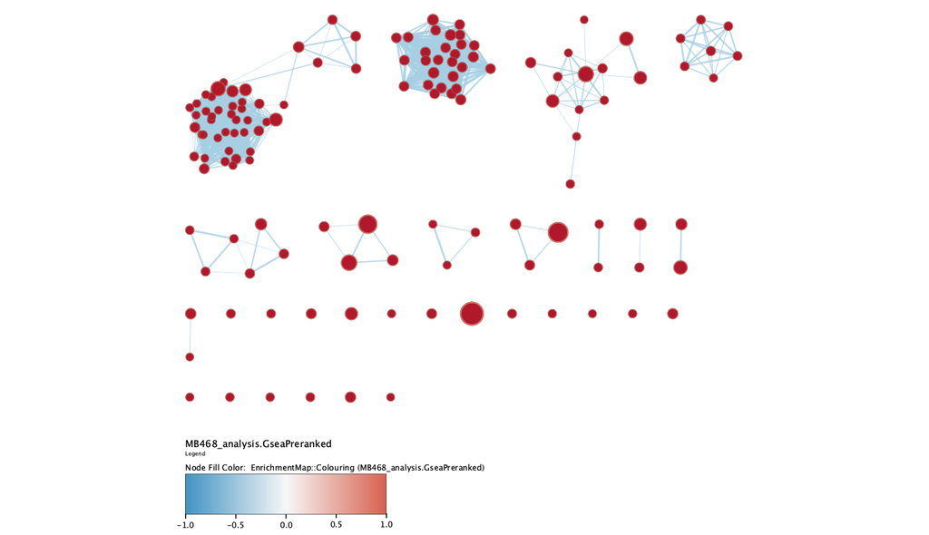

**Figure 1. Initial Enrichment Map for cell line MDA-MB-468.** Each node represents a gene set, and each edge represents an interaction between two gene sets. The size of each node represents the size of the gene set. The colour of the nodes follow the legend and are based on the formula 1 - p-value, multiplied by the sign of the enrichment score.

### Annotated network

The AutoAnnotate app was used to annotate the network (Kucera et al. 2016). Below are the parameters used. All other parameters were set to default.

- Use clusterMaker App ✓
  - Cluster algorithm: MCL Cluster
  - Edge weight column: similarity_coefficient

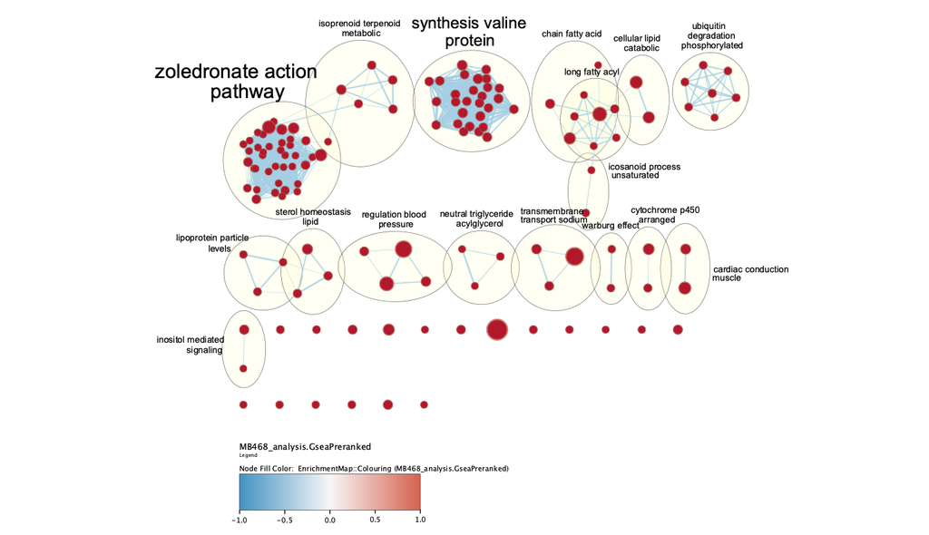

**Figure 2. Annotated Enrichment Map for cell line MDA-MB-468.** Each yellow circle represents a cluster of gene sets. The size of the annotations are proportional to the cluster size.

There are 17 clusters in the network. The size of the annotations are proportional to the cluster size.

### Theme network

A theme network was created by collapsing the above annotated network.

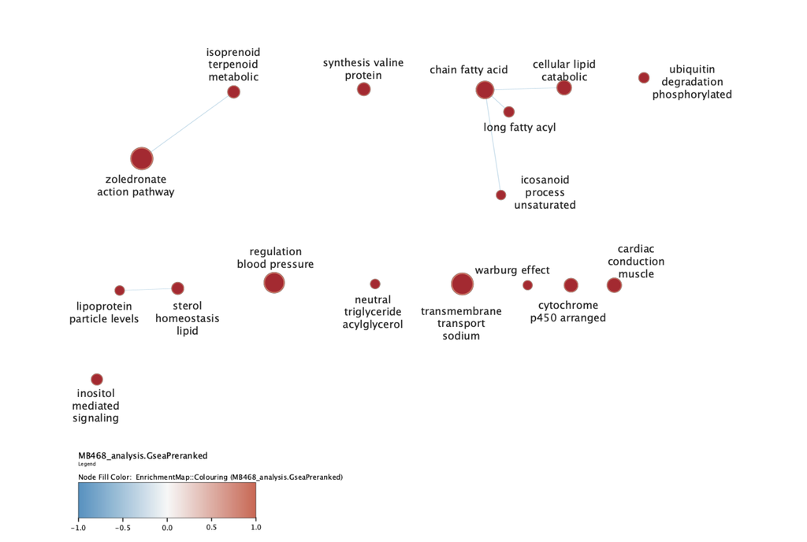

**Figure 3. Theme for cell line MDA-MB-468.** Each node represents a cluster of gene sets. The size of the annotations are proportional to the cluster size.

The largest themes are zoledronate action pathway (39 gene sets) and synthesis valine protein (28 gene sets). The remaining 15 themes have less than 10 gene sets in their clusters.

## MDA-MB-468res-R8

The same approach was applied to the gene set enrichment analysis results for cell line MDA-MB-468res-R8.

### Initial Cytoscape network

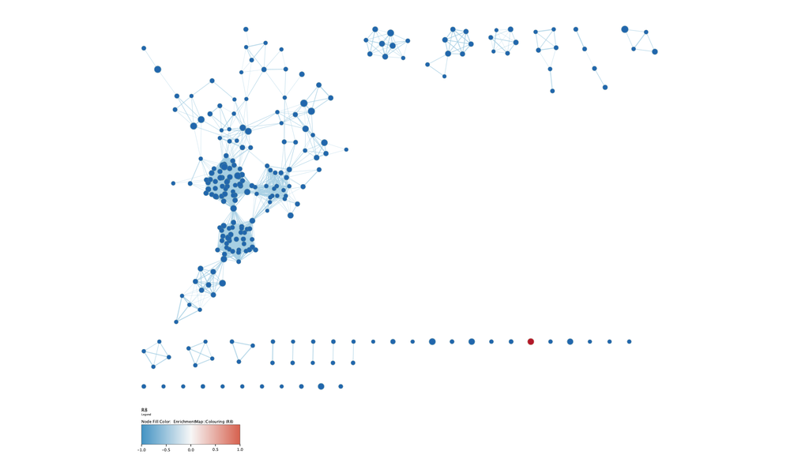

**Figure 4. Initial Enrichment Map for cell line MDA-MB-468res-R8.** Each node represents a gene set, and each edge represents an interaction between two gene sets. The size of each node represents the size of the gene set. The colour of the nodes follow the legend and are based on the formula 1 - p-value, multiplied by the sign of the enrichment score.

### Annotated network

The AutoAnnotate app was used to annotate the network (Kucera et al. 2016). The same parameters that were used for cell line MDA-MB-468 were used for the annotation.

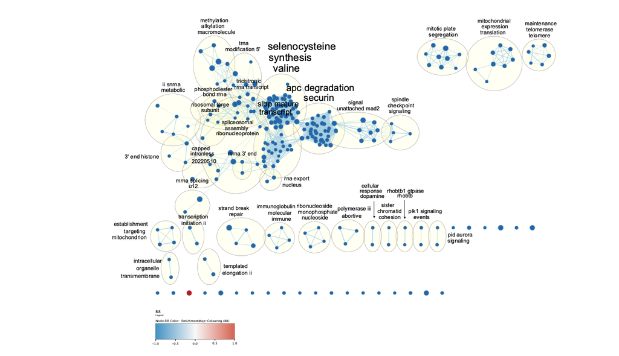

**Figure 5. Annotated Enrichment Map for cell line MDA-MB-468res-R8.** Each yellow circle represents a cluster of gene sets. The size of the annotations are proportional to the cluster size.

There are 33 clusters in the network. The size of the annotations are proportional to the cluster size.

### Theme network

A theme network was created by collapsing the above annotated network.

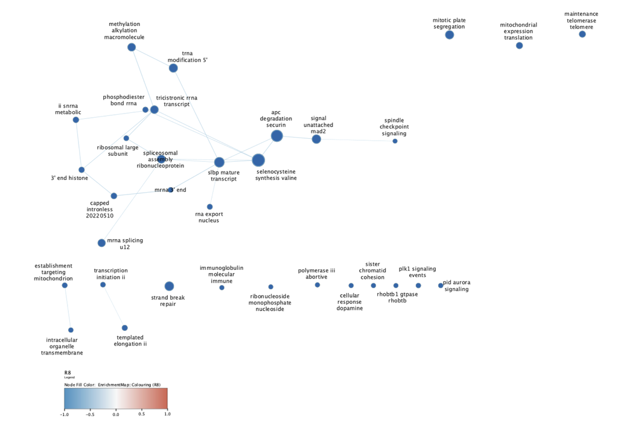

**Figure 6. Theme for cell line MDA-MB-468res-R8.** Each node represents a cluster of gene sets. The size of the annotations are proportional to the cluster size.

The largest themes are selenocysteine synthesis valine (47 gene sets), apc degradation securin (35 gene sets), and slbp mature transcript (22 gene sets). The remaining 30 themes have less than 10 gene sets in their clusters.

# Interpretation and detailed view of results

As stated in the paper, methionine is is the precursor to S-adenosylmethionine (SAM), the main methyl donor in the cell. SAM is a co-factor for a variety of methyltransferases that catalyze methylation events on DNA, RNA, proteins, and lipids (Borrego et al. 2021). Therefore, if methionine stress were added and there were a lack of methionine, core processes on DNA, RNA, proteins, and lipids would be inhibited.

In our GSEA for MDA-MB-468res-R8, major themes of the significantly negatively enriched gene sets when methionine is added the the cell lines are relating to transcription, RNA and genetic related themes.

As stated in the paper, methionine is is the precursor to S-adenosylmethionine (SAM), the main methyl donor in the cell. SAM is a co-factor for a variety of methyltransferases that catalyze methylation events on DNA, RNA, proteins, and lipids (Borrego et al. 2021). Therefore, if methionine stress were added and there were a lack of methionine, core processes on DNA, RNA, proteins, and lipids would be inhibited. The results from the GSEA are consistent with the effects of methionine stress stated in the paper.

**How do these results differ from the results you got from Assignment #2 thresholded methods?** As the GSEA considered all 13078 genes and not just the 49 genes that were found to be significantly differentially expressed in Assignment 2, the results from the GSEA are a lot more comprehensive. The results are also more consistent with the findings in original paper as compared to the threshold methods in Assignment 2.

## Analysis of Sterol Metabolic Process

As lipid response is a key theme in the experiment, I chose to further analyse the Sterol Metabolic Process GO Biological Process Gene Set (GO:0016125). This was also the top positively enirhced gene set for cell line MDA-MB-468.

```r
sterol_met_proc <- read.delim("../data/sterol_metabolic_process.tsv", header = TRUE)

# drop unnecessary columns
sterol_met_proc <- sterol_met_proc[, !(names(sterol_met_proc) %in% c("NAME", "X"))]

kable(head(sterol_met_proc, n = 5), type="html", caption = "Table 6. Head of GSEA results for Sterol Metabolic Process", row.names = FALSE) %>%
  kable_styling()
```

Table 6. Head of GSEA results for Sterol Metabolic Process

| SYMBOL | RANK.IN.GENE.LIST | RANK.METRIC.SCORE | RUNNING.ES | CORE.ENRICHMENT |
| --- | --- | --- | --- | --- |
| INSIG1 | 41 | 0.9037616 | 0.0753278 | Yes |
| HMGCS1 | 161 | 0.5633581 | 0.1151091 | Yes |
| LSS | 210 | 0.5041856 | 0.1552034 | Yes |
| CYP1B1 | 214 | 0.4991604 | 0.1983162 | Yes |
| FAXDC2 | 237 | 0.4777612 | 0.2381122 | Yes |

The results for the genes in the gene set will be used to format the gene network.

```r
genes <- sterol_met_proc[, "SYMBOL"]
# get results for these genes
sterol <- qlf_output_hits_MB468[genes, ]
sterol$gene <- row.names(sterol)
write.table(sterol, "../data/sterol_results.txt", quote = FALSE, sep = "\t", row.names = FALSE)
```

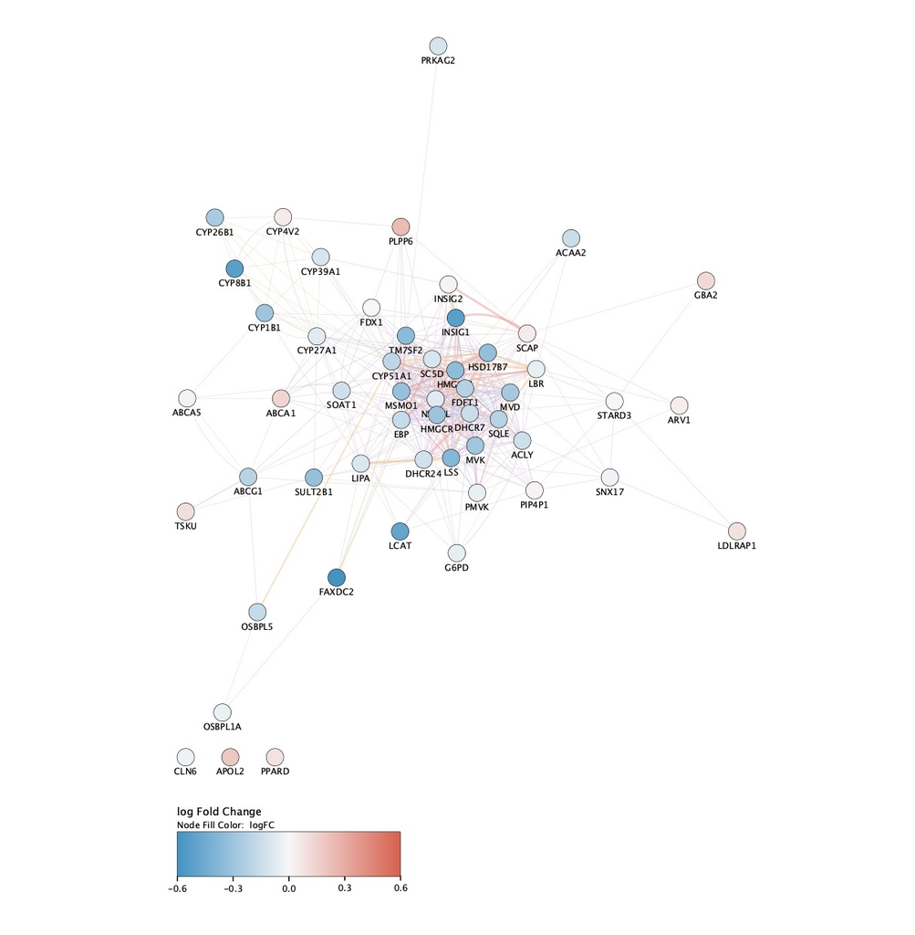

**Figure 7. Gene network for genes in Sterol Metabolic Process GO Biological Process.** The colours of the nodes correspond to their log fold change in expression. Homo sapiens was selected as the organism.

# References

Borrego et al. (2021) Subramanian et al. (2005) Shannon et al. (2003) Merico (2010) Kucera et al. (2016) Chen, Lun, and Smyth (2016) Kolberg et al. (2020) “Zoledronic Acid Monograph for Professionals” (n.d.) Cheng et al. (2018) Warde-Farley et al. (2010)

Borrego, Stacey L., Johannes Fahrmann, Jue Hou, Da-Wei Lin, Bruce J. Tromberg, Oliver Fiehn, and Peter Kaiser. 2021. “Lipid Remodeling in Response to Methionine Stress in MDA-MBA-468 Triple-Negative Breast Cancer Cells.” *Journal of Lipid Research* 62: 100056. https://doi.org/https://doi.org/10.1016/j.jlr.2021.100056.

Chen, Yunshun, Aaron A T Lun, and Gordon K Smyth. 2016. “From Reads to Genes to Pathways: Differential Expression Analysis of RNA-Seq Experiments Using Rsubread and the edgeR Quasi-Likelihood Pipeline.” *F1000Research* 5: 1438. https://doi.org/10.12688/f1000research.8987.2.

Cheng, Lili, Mengmeng Ge, Zhou Lan, Zhilong Ma, Wenna Chi, Wenhua Kuang, Kun Sun, et al. 2018. “Zoledronate Dysregulates Fatty Acid Metabolism in Renal Tubular Epithelial Cells to Induce Nephrotoxicity.” *Arch. Toxicol.* 92 (1): 469–85.

Kolberg, Liis, Uku Raudvere, Ivan Kuzmin, Jaak Vilo, and Hedi Peterson. 2020. “Gprofiler2– an r Package for Gene List Functional Enrichment Analysis and Namespace Conversion Toolset g:profiler.” *F1000Research* 9 (ELIXIR) (709).

Kucera, Mike, Ruth Isserlin, Arkady Arkhangorodsky, and Gary D Bader. 2016. “AutoAnnotate: A Cytoscape App for Summarizing Networks with Semantic Annotations.” *F1000Res.* 5 (July): 1717.

Merico, Ruth AND Stueker, Daniele AND Isserlin. 2010. “Enrichment Map: A Network-Based Method for Gene-Set Enrichment Visualization and Interpretation.” *PLOS ONE* 5 (11): 1–12. https://doi.org/10.1371/journal.pone.0013984.

Shannon, Paul, Andrew Markiel, Owen Ozier, Nitin S Baliga, Jonathan T Wang, Daniel Ramage, Nada Amin, Benno Schwikowski, and Trey Ideker. 2003. “Cytoscape: A Software Environment for Integrated Models of Biomolecular Interaction Networks.” *Genome Research* 13 (11): 2498–2504.

Subramanian, Aravind, Pablo Tamayo, Vamsi K. Mootha, Sayan Mukherjee, Benjamin L. Ebert, Michael A. Gillette, Amanda Paulovich, et al. 2005. “Gene Set Enrichment Analysis: A Knowledge-Based Approach for Interpreting Genome-Wide Expression Profiles.” *Proceedings of the National Academy of Sciences* 102 (43): 15545–50. https://doi.org/10.1073/pnas.0506580102.

Warde-Farley, David, Sylva L Donaldson, Ovi Comes, Khalid Zuberi, Rashad Badrawi, Pauline Chao, Max Franz, et al. 2010. “The GeneMANIA Prediction Server: Biological Network Integration for Gene Prioritization and Predicting Gene Function.” *Nucleic Acids Res.* 38 (Web Server issue): W214–20.

“Zoledronic Acid Monograph for Professionals.” n.d. *Drugs.com*. https://www.drugs.com/monograph/zoledronic-acid.html.